# tutorial11-example-analysis

## Tutorial 11: Example Analysis of American Authors

In this tutorial, we combine all of our skills from the semester so far (as well as some new libraries) to do an actual data analysis from Wikipedia.

### Question of interest

In this tutorial we will focus on collecting Wikipedia data from a list of American novelists. Our initial question of interest will be figuring out the relationship between several metrics within the pages that all, in their own way, indicate how prominently a given author is represented. We will see how to store this data as CSV file as well as how to produce interactive graphics to explore the dataset.

### wiki.py

Last time we found a bug in my `wiki.py` code. Please re-download and replace the script with the original. The following loads the module and checks that you have version 2 or higher (if there is no error, it works!):

```python
import wiki

assert wiki.__version__ >= 2
```

### Getting the data

There is a list on Wikipedia of pages for American novelists. Please start by looking at the page in your browser:

- https://en.wikipedia.org/wiki/List_of_American_novelists

Notice that many of the links on this page are to specific novels by an author. There are also links at the top and bottom of the page before the actual lists starts. We don't want these in our analysis! In order to just grab links to actual authors, we need to use regular expressions and parse data directly from the page.

Start by loading the `re` module

```python
import re
```

Next, grab the page for the list of American novelists. We'll need the actual text of the page, which I print out the first 1000 characters of here for reference:

```python
data = wiki.get_wiki_json("List_of_American_novelists")
data_html = data['text']['*']
print(data_html[:1000])
```

```
Pulling data from MediaWiki API: 'List_of_American_novelists'
<div class="mw-parser-output"><div role="note" class="hatnote navigation-not-searchable">Main category: <a href="/wiki/Category:American_novelists" title="Category:American novelists">American novelists</a></div>
<p>This is a <b>list of <a href="/wiki/Novelist" title="Novelist">novelists</a> from the <a href="/wiki/United_States" title="United States">United States</a></b>, listed with titles of a major work for each.
</p><p>This is not intended to be a list of every American (born U.S. citizen, naturalized citizen, or long-time resident alien) who has published a <a href="/wiki/Novel" title="Novel">novel</a>. (For the purposes of this article, <i>novel</i> is defined as an extended work of <a href="/wiki/Fiction…
```

In order to *just* get authors, a trick we can use on this page is to only find links that come after the HTML tag `<li>` (a list item). This will avoid most of links we don't want, but will accidentally grab a few at the bottom of the page. We deal with those in a moment. Here is the regular expression that grabs the pages of interest.

```python
authors = re.findall('<li><a href="/wiki/([^"]+)"', data_html)
authors[:10]
```

```
['Patricia_Aakhus',
 'Atia_Abawi',
 'Edward_Abbey',
 'Lynn_Abbey',
 'Belle_Kendrick_Abbott',
 'Eleanor_Hallowell_Abbott',
 'Hailey_Abbott',
 'Megan_Abbott',
 'Shana_Ab%C3%A9',
 'Louise_Abeita']
```

The list of authors includes over 1600 pages.

```python
len(authors)
```

```
1612
```

Notice that the list includes a few links at the bottom that we do not actually want in our data.

```python
authors[-40:]
```

```
['Anzia_Yezierska',
 'Rafael_Yglesias',
 'Mako_Yoshikawa',
 'Al_Young',
 'Stark_Young',
 'Michele_Young-Stone',
 'Rafi_Zabor',
 'Roger_Zelazny',
 'Paul_Zindel',
 'Nell_Zink',
 'Leane_Zugsmith',
 'American_literature',
 'Colonial_American_literature',
 'Southern_literature',
 'African_American_literature',
 'Jewish_American_literature',
 'LGBT_literature',
 'Lists_of_writers',
 'List_of_short_story_authors',
 'List_of_novelists_by_nationality',
 'List_of_women_writers',
 'List_of_African-American_writers',
 'List_of_Asian-American_writers',
 'List_of_Jewish_American_authors',
 'List_of_writers_from_peoples_indigenous_to_the_Americas',
 'Pulitzer_Prize_for_the_Novel',
 'Pulitzer_Prize_for_Fiction',
 'National_Book_Award',
 'Bestseller',
 'Publishers_Weekly_lists_of_bestselling_novels_in_the_United_States',
 'List_of_Australian_novelists',
 'List_of_English_novelists',
 'List_of_French_novelists',
 'List_of_Ghanaian_novelists',
 'List_of_Irish_novelists',
 'List_of_Korean_novelists',
 'List_of_Nigerian_novelists',
 'List_of_Polish_novelists',
 'List_of_Portuguese_novelists',
 'List_of_Scottish_novelists']
```

We will 'cut-off' the list of authors manually with the follow code (similar to how I cut out the header and footer of the raw HTML code in Tutorial 6).

```python
authors = authors[:(authors.index('Leane_Zugsmith') + 1)]
authors[-10:]
```

```
['Rafael_Yglesias',
 'Mako_Yoshikawa',
 'Al_Young',
 'Stark_Young',
 'Michele_Young-Stone',
 'Rafi_Zabor',
 'Roger_Zelazny',
 'Paul_Zindel',
 'Nell_Zink',
 'Leane_Zugsmith']
```

Now that we have our list of authors, let's grab them all (or verify that we have all of the links already).

```python
for link in authors:
    wiki.get_wiki_json(link)
```

### Page metrics

Now that we have the pages for each of the authors, we want to gather a number of metrics about each page. To write code that does this, typically I start by playing around with a single page and *then* wrap it all up in a `for` loop.

For example, I wrote and tested the following code to figure out several metrics of interest:

```python
# load a single page of data
data = wiki.get_wiki_json("Mark_Twain")
```

```python
# (1) get the title of the page
data['title']
```

```
'Mark Twain'
```

```python
# (2) determine the number of links to other languages
len(data['langlinks'])
```

```
140
```

```python
# (3) determine number of internal links
len(data['links'])
```

```
733
```

```python
# (4) determine number of characters in the text of the page
len(data['text']['*'])
```

```
345621
```

```python
# (5) determine number of external links
len(data['externallinks'])
```

```
144
```

You can use similar code to compute other metrics, such as the number of images used on the page.

### Aggregating metrics

Now, we will use a `for` loop to collect the metadata and metrics described in the prior section for each Wikipedia page in our corpus. We cycle through each author, appending the new metric values to the lists at the top of the code block. Fill in the information inside of the `for` loop to append the metrics to each page.

```python
author_name = []
num_langs = []
num_links = []
num_chars = []
num_elinks = []

for link in authors:
    data = wiki.get_wiki_json(link)

    author_name.append(data['title'])
    num_langs.append(len(data['langlinks']))
    num_links.append(len(data['links']))
    num_chars.append(len(data['text']['*']))
    num_elinks.append(len(data['externallinks']))
```

Now, it will be useful to put all of this data together in a single table. The standard library for working with tabular data in Python is called **pandas**, which we import here:

```python
import pandas as pd
```

The object that stores tabular data in pandas is called a `DataFrame` (yes, it's based on the data frame object native to R). There are many ways to build a data frame object from a collection of lists, but this block below illustrates my favorite method using an `OrderedDict`. Below, I'll print out a copy of the table (notice that it prints nicely in a the Jupyter notebook).

```python
import collections

df = collections.OrderedDict()
df['author_name'] = author_name
df['url'] = authors
df['num_langs'] = num_langs
df['num_links'] = num_links
df['num_chars'] = num_chars
df['num_elinks'] = num_elinks

df = pd.DataFrame(df)
df
```

|  | author_name | url | num_langs | num_links | num_chars | num_elinks |
| --- | --- | --- | --- | --- | --- | --- |
| 0 | Patricia Aakhus | Patricia_Aakhus | 4 | 18 | 16048 | 11 |
| 1 | Atia Abawi | Atia_Abawi | 1 | 49 | 29361 | 25 |
| 2 | Edward Abbey | Edward_Abbey | 14 | 179 | 129965 | 71 |
| 3 | Lynn Abbey | Lynn_Abbey | 9 | 339 | 72752 | 22 |
| 4 | Belle Kendrick Abbott | Belle_Kendrick_Abbott | 0 | 22 | 10906 | 8 |
| 5 | Eleanor Hallowell Abbott | Eleanor_Hallowell_Abbott | 10 | 133 | 41495 | 15 |
| 6 | Hailey Abbott | Hailey_Abbott | 0 | 19 | 9818 | 10 |
| 7 | Megan Abbott | Megan_Abbott | 10 | 47 | 31586 | 25 |
| 8 | Shana Abé | Shana_Ab%C3%A9 | 1 | 17 | 15169 | 11 |
| 9 | Louise Abeita | Louise_Abeita | 0 | 27 | 17743 | 7 |
| 10 | Robert H. Abel | Robert_H._Abel | 1 | 26 | 23803 | 17 |
| 11 | Aberjhani | Aberjhani | 1 | 106 | 56226 | 33 |
| 12 | Walter Abish | Walter_Abish | 9 | 63 | 22916 | 17 |
| 13 | Abiola Abrams | Abiola_Abrams | 1 | 78 | 39768 | 33 |
| 14 | Diana Abu-Jaber | Diana_Abu-Jaber | 1 | 50 | 18957 | 17 |
| 15 | Susan Abulhawa | Susan_Abulhawa | 10 | 37 | 35559 | 34 |
| 16 | Kathy Acker | Kathy_Acker | 18 | 173 | 95423 | 72 |
| 17 | Cherry Adair | Cherry_Adair | 1 | 26 | 31689 | 21 |
| 18 | Alice Adams (writer) | Alice_Adams_(writer) | 1 | 35 | 25544 | 16 |
| 19 | Henry Brooks Adams | Henry_Brooks_Adams | 0 | 1 | 958 | 0 |
| 20 | Yda Addis | Yda_Addis | 0 | 1 | 972 | 0 |
| 21 | Kim Addonizio | Kim_Addonizio | 3 | 34 | 34623 | 36 |
| 22 | George Ade | George_Ade | 8 | 64 | 40080 | 23 |
| 23 | Renata Adler | Renata_Adler | 4 | 86 | 45092 | 27 |
| 24 | Warren Adler | Warren_Adler | 6 | 58 | 38336 | 25 |
| 25 | James Agee | James_Agee | 26 | 310 | 75178 | 42 |
| 26 | Charlotte Agell | Charlotte_Agell | 2 | 39 | 87868 | 17 |
| 27 | Kelli Russell Agodon | Kelli_Russell_Agodon | 0 | 15 | 24826 | 27 |
| 28 | Conrad Aiken | Conrad_Aiken | 26 | 166 | 60924 | 49 |
| 29 | Hiag Akmakjian | Hiag_Akmakjian | 2 | 30 | 30156 | 19 |
| ... | ... | ... | ... | ... | ... | ... |
| 1553 | Samuel Woodworth | Samuel_Woodworth | 0 | 39 | 24215 | 19 |
| 1554 | Cornell Woolrich | Cornell_Woolrich | 18 | 157 | 47176 | 25 |
| 1555 | Constance Fenimore Woolson | Constance_Fenimore_Woolson | 7 | 69 | 74045 | 24 |
| 1556 | Herman Wouk | Herman_Wouk | 28 | 343 | 93201 | 48 |
| 1557 | Austin Tappan Wright | Austin_Tappan_Wright | 1 | 58 | 25321 | 12 |
| 1558 | Ernest Vincent Wright | Ernest_Vincent_Wright | 7 | 16 | 17895 | 12 |
| 1559 | Harold Bell Wright | Harold_Bell_Wright | 1 | 84 | 45844 | 25 |
| 1560 | Kirby Wright | Kirby_Wright | 0 | 61 | 23988 | 10 |
| 1561 | Mary Tappan Wright | Mary_Tappan_Wright | 1 | 49 | 55425 | 65 |
| 1562 | Richard Wright (author) | Richard_Wright_(author) | 27 | 195 | 117945 | 63 |
| 1563 | Stephen Wright (writer) | Stephen_Wright_(writer) | 0 | 30 | 14062 | 10 |
| 1564 | Xu Xi (writer) | Xu_Xi_(writer) | 1 | 38 | 27696 | 23 |
| 1565 | Irvin D. Yalom | Irvin_D._Yalom | 24 | 258 | 62451 | 31 |
| 1566 | Lois-Ann Yamanaka | Lois-Ann_Yamanaka | 0 | 54 | 26022 | 17 |
| 1567 | Karen Tei Yamashita | Karen_Tei_Yamashita | 1 | 40 | 24342 | 23 |
| 1568 | Chelsea Quinn Yarbro | Chelsea_Quinn_Yarbro | 3 | 133 | 39965 | 28 |
| 1569 | Steve Yarbrough (writer) | Steve_Yarbrough_(writer) | 0 | 32 | 12918 | 13 |
| 1570 | Richard Yates (novelist) | Richard_Yates_(novelist) | 15 | 132 | 49604 | 33 |
| 1571 | Frank Yerby | Frank_Yerby | 3 | 49 | 33063 | 23 |
| 1572 | Anzia Yezierska | Anzia_Yezierska | 5 | 68 | 43655 | 39 |
| 1573 | Rafael Yglesias | Rafael_Yglesias | 2 | 66 | 21878 | 17 |
| 1574 | Mako Yoshikawa | Mako_Yoshikawa | 1 | 22 | 14999 | 14 |
| 1575 | Al Young | Al_Young | 0 | 71 | 30751 | 32 |
| 1576 | Stark Young | Stark_Young | 0 | 41 | 17200 | 13 |
| 1577 | Michele Young-Stone | Michele_Young-Stone | 0 | 19 | 14284 | 12 |
| 1578 | Rafi Zabor | Rafi_Zabor | 1 | 34 | 18731 | 17 |
| 1579 | Roger Zelazny | Roger_Zelazny | 35 | 177 | 74495 | 32 |
| 1580 | Paul Zindel | Paul_Zindel | 5 | 190 | 51223 | 22 |
| 1581 | Nell Zink | Nell_Zink | 2 | 52 | 43856 | 30 |
| 1582 | Leane Zugsmith | Leane_Zugsmith | 0 | 33 | 19704 | 13 |

1583 rows × 6 columns

Pandas has a convenient method for storing a table of data as a CSV (comma seperated values) file. Running the code below will save the table as the file "american_authors.csv"; it can be read into programs such as Excel, Googe Sheets, and other programming languages.

```python
df.to_csv("american_authors.csv", index=False)
```

If you open the file browser, you'll see the CSV file show up in your 'tutorials' directory. You can similarly read a csv file back in Python using the `pd.read_csv` function.

```python
new_df = pd.read_csv("american_authors.csv")
new_df
```

|  | author_name | url | num_langs | num_links | num_chars | num_elinks |
| --- | --- | --- | --- | --- | --- | --- |
| 0 | Patricia Aakhus | Patricia_Aakhus | 4 | 18 | 16048 | 11 |
| 1 | Atia Abawi | Atia_Abawi | 1 | 49 | 29361 | 25 |
| 2 | Edward Abbey | Edward_Abbey | 14 | 179 | 129965 | 71 |
| 3 | Lynn Abbey | Lynn_Abbey | 9 | 339 | 72752 | 22 |
| 4 | Belle Kendrick Abbott | Belle_Kendrick_Abbott | 0 | 22 | 10906 | 8 |
| 5 | Eleanor Hallowell Abbott | Eleanor_Hallowell_Abbott | 10 | 133 | 41495 | 15 |
| 6 | Hailey Abbott | Hailey_Abbott | 0 | 19 | 9818 | 10 |
| 7 | Megan Abbott | Megan_Abbott | 10 | 47 | 31586 | 25 |
| 8 | Shana Abé | Shana_Ab%C3%A9 | 1 | 17 | 15169 | 11 |
| 9 | Louise Abeita | Louise_Abeita | 0 | 27 | 17743 | 7 |
| 10 | Robert H. Abel | Robert_H._Abel | 1 | 26 | 23803 | 17 |
| 11 | Aberjhani | Aberjhani | 1 | 106 | 56226 | 33 |
| 12 | Walter Abish | Walter_Abish | 9 | 63 | 22916 | 17 |
| 13 | Abiola Abrams | Abiola_Abrams | 1 | 78 | 39768 | 33 |
| 14 | Diana Abu-Jaber | Diana_Abu-Jaber | 1 | 50 | 18957 | 17 |
| 15 | Susan Abulhawa | Susan_Abulhawa | 10 | 37 | 35559 | 34 |
| 16 | Kathy Acker | Kathy_Acker | 18 | 173 | 95423 | 72 |
| 17 | Cherry Adair | Cherry_Adair | 1 | 26 | 31689 | 21 |
| 18 | Alice Adams (writer) | Alice_Adams_(writer) | 1 | 35 | 25544 | 16 |
| 19 | Henry Brooks Adams | Henry_Brooks_Adams | 0 | 1 | 958 | 0 |
| 20 | Yda Addis | Yda_Addis | 0 | 1 | 972 | 0 |
| 21 | Kim Addonizio | Kim_Addonizio | 3 | 34 | 34623 | 36 |
| 22 | George Ade | George_Ade | 8 | 64 | 40080 | 23 |
| 23 | Renata Adler | Renata_Adler | 4 | 86 | 45092 | 27 |
| 24 | Warren Adler | Warren_Adler | 6 | 58 | 38336 | 25 |
| 25 | James Agee | James_Agee | 26 | 310 | 75178 | 42 |
| 26 | Charlotte Agell | Charlotte_Agell | 2 | 39 | 87868 | 17 |
| 27 | Kelli Russell Agodon | Kelli_Russell_Agodon | 0 | 15 | 24826 | 27 |
| 28 | Conrad Aiken | Conrad_Aiken | 26 | 166 | 60924 | 49 |
| 29 | Hiag Akmakjian | Hiag_Akmakjian | 2 | 30 | 30156 | 19 |
| ... | ... | ... | ... | ... | ... | ... |
| 1553 | Samuel Woodworth | Samuel_Woodworth | 0 | 39 | 24215 | 19 |
| 1554 | Cornell Woolrich | Cornell_Woolrich | 18 | 157 | 47176 | 25 |
| 1555 | Constance Fenimore Woolson | Constance_Fenimore_Woolson | 7 | 69 | 74045 | 24 |
| 1556 | Herman Wouk | Herman_Wouk | 28 | 343 | 93201 | 48 |
| 1557 | Austin Tappan Wright | Austin_Tappan_Wright | 1 | 58 | 25321 | 12 |
| 1558 | Ernest Vincent Wright | Ernest_Vincent_Wright | 7 | 16 | 17895 | 12 |
| 1559 | Harold Bell Wright | Harold_Bell_Wright | 1 | 84 | 45844 | 25 |
| 1560 | Kirby Wright | Kirby_Wright | 0 | 61 | 23988 | 10 |
| 1561 | Mary Tappan Wright | Mary_Tappan_Wright | 1 | 49 | 55425 | 65 |
| 1562 | Richard Wright (author) | Richard_Wright_(author) | 27 | 195 | 117945 | 63 |
| 1563 | Stephen Wright (writer) | Stephen_Wright_(writer) | 0 | 30 | 14062 | 10 |
| 1564 | Xu Xi (writer) | Xu_Xi_(writer) | 1 | 38 | 27696 | 23 |
| 1565 | Irvin D. Yalom | Irvin_D._Yalom | 24 | 258 | 62451 | 31 |
| 1566 | Lois-Ann Yamanaka | Lois-Ann_Yamanaka | 0 | 54 | 26022 | 17 |
| 1567 | Karen Tei Yamashita | Karen_Tei_Yamashita | 1 | 40 | 24342 | 23 |
| 1568 | Chelsea Quinn Yarbro | Chelsea_Quinn_Yarbro | 3 | 133 | 39965 | 28 |
| 1569 | Steve Yarbrough (writer) | Steve_Yarbrough_(writer) | 0 | 32 | 12918 | 13 |
| 1570 | Richard Yates (novelist) | Richard_Yates_(novelist) | 15 | 132 | 49604 | 33 |
| 1571 | Frank Yerby | Frank_Yerby | 3 | 49 | 33063 | 23 |
| 1572 | Anzia Yezierska | Anzia_Yezierska | 5 | 68 | 43655 | 39 |
| 1573 | Rafael Yglesias | Rafael_Yglesias | 2 | 66 | 21878 | 17 |
| 1574 | Mako Yoshikawa | Mako_Yoshikawa | 1 | 22 | 14999 | 14 |
| 1575 | Al Young | Al_Young | 0 | 71 | 30751 | 32 |
| 1576 | Stark Young | Stark_Young | 0 | 41 | 17200 | 13 |
| 1577 | Michele Young-Stone | Michele_Young-Stone | 0 | 19 | 14284 | 12 |
| 1578 | Rafi Zabor | Rafi_Zabor | 1 | 34 | 18731 | 17 |
| 1579 | Roger Zelazny | Roger_Zelazny | 35 | 177 | 74495 | 32 |
| 1580 | Paul Zindel | Paul_Zindel | 5 | 190 | 51223 | 22 |
| 1581 | Nell Zink | Nell_Zink | 2 | 52 | 43856 | 30 |
| 1582 | Leane Zugsmith | Leane_Zugsmith | 0 | 33 | 19704 | 13 |

1583 rows × 6 columns

### Plotting data

Another useful feature of the Pandas library is that it makes it easy to produce plots of the data stored within a table. Here is some example code for producing a scatter plot from our Pandas dataset

```python
%matplotlib inline
import matplotlib
```

```python
matplotlib.rcParams['figure.figsize'] = (20.0, 10.0)
```

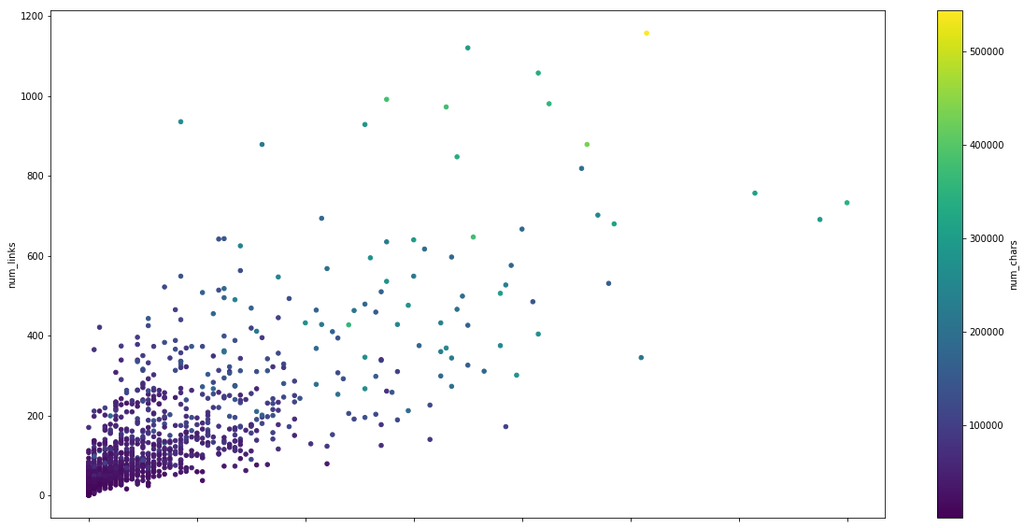

```python
df.plot.scatter(x='num_langs',
                y='num_links',
                c='num_chars',
                colormap='viridis')
```

You can modify the `figure.figsize` parameter based on the size of your computer screen.

### Interactive plotting with Bokeh

The static plot above is okay, but it's much more interesting to create an interactive graphic. To do this we will use the `bokeh` module. Load the required functions from `bokeh` below and specify that the output should appear within the Jupyter notebook.

```python
from bokeh.plotting import figure, show, output_notebook, ColumnDataSource

output_notebook()
```

Now, the code block below produces an interactive scatter plot. You can pan and zoom the plot depending on what parts of the plot you find interesting. Also, perhaps most importantly, if you hover over a point the name of the author associated with the point will show up. Try it!

```python
TOOLTIPS = [
    ("Author", "@author_name"),
    ("Number Internal Links", "@num_links"),
    ("Number External Links", "@num_elinks"),
]

p = figure(plot_width=950,
           plot_height=500,
           tooltips=TOOLTIPS,
           tools="hover,pan,wheel_zoom,reset",
           toolbar_location="below",
           toolbar_sticky=True,
           active_scroll='wheel_zoom',
           title="American Authors - Wikipedia Data",
           x_axis_label="Number of Language Pages",
           y_axis_label="Number of Internal Links")

p.circle(x='num_langs',
         y='num_links',
         size=10,
         fill_alpha=0.5,
         source=ColumnDataSource(data=df))

show(p)
```

[interactive chart not shown]

You won't understand all of the components of the plot immediately, but hopefully the example shows enough so that you could modify the plot to include different variables or a different set of information when hovering over the points.

Finally, the plot below makes use of the `OpenURL` and `TapTool` models to make the points clickable. Tapping on a point will open the Wikipedia page in a new tab. Try it now!

```python
from bokeh.models import OpenURL, TapTool

TOOLTIPS = [
    ("Author", "@author_name"),
    ("Number Internal Links", "@num_links"),
    ("Number External Links", "@num_elinks"),
]

p = figure(plot_width=950,
           plot_height=500,
           tooltips=TOOLTIPS,
           tools="hover,pan,wheel_zoom,reset,tap",
           toolbar_location="below",
           toolbar_sticky=True,
           active_scroll='wheel_zoom',
           title="American Authors - Wikipedia Data",
           x_axis_label="Number of Language Pages",
           y_axis_label="Number of Internal Links")

p.circle(x='num_langs',
         y='num_links',
         size=10,
         fill_alpha=0.5,
         source=ColumnDataSource(data=df))

taptool = p.select(type=TapTool)
taptool.callback = OpenURL(url="https://en.wikipedia.org/wiki/@url")

show(p)
```

[interactive chart not shown]

Rather than a formal practice set of questions, today you will start working on your first project, which uses the methods developed in this tutorial to analyze a new dataset.

### More practice

Feel free to check out the bokeh reference guide (note: it's huge!):

- https://bokeh.pydata.org/en/latest/docs/reference.html

In particular check out the Gallary and demos. If you are interested in data visualization, there will be several of chances to build out interesting bokeh-based applications later this semester.